# Part_ii_Regression_B

Yijun Zhou

4/26/2022

# OVERVIEW of B

The aim of this part is consider the uncertainty on the residual error through Bayesian modeling techniques;  
1) Fit 2 Bayesian linear models-one must be the best model from iiA) and the second must be another model you fit in iiA);  
2)state why you chose the second model  
3)identify the best model and which performance metric you used to make your selection  
4)visualize the regression coefficient posterior summary statistics for your best model  
5)for your best model:study the posterior uncertainty in the noise(residual error),$\sigma$,  
how does the lm() maximum likelihood estimate(MLE) on $\sigma$ relate to the posterior uncertainty on $\sigma$?  
6)Do you feel the posterior is precise or are we quite uncertain about $\sigma$

## load packages

```r
library(tidyverse)
library(caret)
```

```r
library(coefplot)
library(rstanarm)
```

## read data set

```r
df_all <- readr::read_csv("final_project_train.csv", col_names = TRUE)
df_all<-df_all %>%mutate(log_response=log(response))%>%
  select(-rowid,-outcome,-response)%>%glimpse()
```

```
## Rows: 677
## Columns: 36
## $ region       <chr> "XX", "XX", "XX", "XX", "XX", "XX", "XX", "XX", "XX", "XX…
## $ customer     <chr> "B", "B", "B", "B", "B", "B", "B", "B", "B", "B", "B", "B…
## $ xb_01        <dbl> 4.000000, 1.000000, 2.000000, 2.520000, 2.548387, 3.07142…
## $ xb_02        <dbl> 4, 1, 2, 11, 6, 6, 10, 12, 9, 10, 8, 10, 10, 8, 6, 10, 13…
## $ xb_03        <dbl> 4, 1, 2, -6, -1, 1, -4, -4, -2, -4, -2, -2, -2, -4, 1, -4…
## $ xn_01        <dbl> 3.0000000, 2.0000000, 2.0000000, 1.5333333, 0.8387097, 1.…
## $ xn_02        <dbl> 3, 2, 4, 9, 3, 8, 6, 10, 10, 4, 6, 8, 9, 5, 7, 12, 12, 6,…
## $ xn_03        <dbl> 3, 2, 0, -3, -4, -2, -5, -6, -3, -5, -3, -6, -4, -3, 0, -…
## $ xa_01        <dbl> 12.000000, 3.000000, 9.000000, 7.080000, 6.451613, 6.8571…
## $ xa_02        <dbl> 12, 3, 9, 29, 17, 18, 24, 27, 20, 19, 15, 24, 24, 15, 14,…
## $ xa_03        <dbl> 12, 3, 9, -7, -2, 2, -9, -5, -3, -3, -1, 1, -2, -3, 3, -4…
## $ xb_04        <dbl> 1.3333333, 1.0000000, 1.0000000, 0.8950476, 1.2247312, 1.…
## $ xb_05        <dbl> 1.3333333, 1.0000000, 1.0000000, -2.0000000, -0.5000000, …
```

[output cut: 23 more lines]

### fit Bayesian linear model of the best model from iiA

```r
set.seed(2347)
train_id<-sample(1:nrow(df_all),size=floor(0.7*nrow(df_all)))
train_df_all<-df_all %>%slice(train_id)
test_df_all<-df_all %>%slice(-train_id)
```

Based on the analysis above, the best model is model3-all categorical and continuous variables-linear additive

```r
Xmat_3_train <-model.matrix(~.,data=train_df_all%>%select(-log_response))
Xmat_3_test<-model.matrix(~.,data=test_df_all%>%select(-log_response))
info_3_weak<-list(
  yobs=train_df_all$log_response,
  design_matrix=Xmat_3_train,
  mu_beta=0,
  tau_beta=50,
  sigma_rate=1
)
ncol(Xmat_3_train)
```

```
## [1] 44
```

```r
info_3_strong<-list(
  yobs=train_df_all$log_response,
  design_matrix=Xmat_3_train,
  mu_beta=0,
  tau_beta=1/50,
  sigma_rate=1
)
```

### model 8(my choice): model 8 has the lowest value of BIC among my models

```r
Xmat_8_train <-model.matrix(~splines::ns(xw_01,2)*.,data=train_df_all%>%select(-log_response))
Xmat_8_test<-model.matrix(~splines::ns(xw_01,2)*.,data=test_df_all%>%select(-log_response))
info_8_weak<-list(
  yobs=train_df_all$log_response,
  design_matrix=Xmat_8_train,
  mu_beta=0,
  tau_beta=50,
  sigma_rate=1
)
info_8_strong<-list(
  yobs=train_df_all$log_response,
  design_matrix=Xmat_8_train,
  mu_beta=0,
  tau_beta=1/50,
  sigma_rate=1
)
```

```r
lm_logpost <- function(unknowns, my_info)
{
  # specify the number of unknown beta parameters
  length_beta <- ncol(my_info$design_matrix)

  # extract the beta parameters from the `unknowns` vector
  beta_v <- unknowns[1:length_beta]

  # extract the unbounded noise parameter, varphi
  lik_varphi <- unknowns[length_beta + 1]

  # back-transform from varphi to sigma
  lik_sigma <- exp(lik_varphi)

  # extract design matrix
  X <- my_info$design_matrix

  # calculate the linear predictor
  mu <- as.matrix(X) %*% as.matrix(beta_v)

  # evaluate the log-likelihood
  log_lik <- sum(dnorm(x=my_info$yobs,
                       mean=mu,
                       sd=lik_sigma,
                       log=TRUE))

  # evaluate the log-prior
  log_prior_beta <- sum(dnorm(x=beta_v,
                              mean=my_info$mu_beta,
                              sd=my_info$tau_beta,
                              log=TRUE))

  log_prior_sigma <- -my_info$sigma_rate*lik_sigma

  # add the mean trend prior and noise prior together
  log_prior <- log_prior_beta+log_prior_sigma

  # account for the transformation
  log_derive_adjust <- lik_varphi

  # sum together
  log_lik+log_prior+log_derive_adjust
}
```

```r
my_laplace <- function(start_guess, logpost_func, ...)
{
  # code adapted from the `LearnBayes`` function `laplace()`
  fit <- optim(start_guess,
               logpost_func,
               gr = NULL,
               ...,
               method = "BFGS",
               hessian = TRUE,
               control = list(fnscale = -1, maxit = 1001))

  mode <- fit$par
  post_var_matrix <- -solve(fit$hessian)
  p <- length(mode)
  int <- p/2 * log(2 * pi) + 0.5 * log(det(post_var_matrix)) + logpost_func(mode, ...)
  # package all of the results into a list
  list(mode = mode,
       var_matrix = post_var_matrix,
       log_evidence = int,
       converge = ifelse(fit$convergence == 0,
                         "YES",
                         "NO"),
       iter_counts = as.numeric(fit$counts[1]))
}
```

```r
laplace_3_weak<-
  my_laplace(numeric(ncol(info_3_weak$design_matrix)+1),lm_logpost,info_3_weak)
laplace_8_weak<-
  my_laplace(numeric(ncol(info_8_weak$design_matrix)+1),lm_logpost,info_8_weak)
laplace_3_strong<-
  my_laplace(numeric(ncol(info_3_strong$design_matrix)+1),lm_logpost,info_3_strong)
laplace_8_strong<-
  my_laplace(numeric(ncol(info_8_strong$design_matrix)+1),lm_logpost,info_8_strong)
```

```r
generate_lm_post_samples <- function(mvn_result, length_beta, num_samples)
{
  MASS::mvrnorm(n = num_samples,
                mu = mvn_result$mode,
                Sigma = mvn_result$var_matrix) %>%
    as.data.frame() %>% tibble::as_tibble() %>%
    purrr::set_names(c(sprintf("beta_%02d", 0:(length_beta-1)), "varphi")) %>%
    mutate(sigma = exp(varphi))
}
```

```r
set.seed(83757)
post_samples_3_weak <-
  generate_lm_post_samples(laplace_3_weak, ncol(Xmat_3_train), 2500)
post_samples_8_weak <-
  generate_lm_post_samples(laplace_8_weak, ncol(Xmat_8_train), 2500)
post_samples_3_strong<-
  generate_lm_post_samples(laplace_3_strong,ncol(Xmat_3_train),2500)
post_samples_8_strong<-
  generate_lm_post_samples(laplace_8_strong,ncol(Xmat_8_train),2500)
```

```r
post_lm_pred_samples <- function(Xnew, Bmat, sigma_vector)
{
  # number of new prediction locations
  M <- nrow(Xnew)
  # number of posterior samples
  S <- nrow(Bmat)

  # matrix of linear predictors
  Umat <- Xnew %*% t(Bmat)

  # assmeble matrix of sigma samples, set the number of rows
  Rmat <- matrix(rep(sigma_vector, M), M, byrow = TRUE)

  # generate standard normal and assemble into matrix
  # set the number of rows
  Zmat <- matrix(rnorm(M*S), M, byrow = TRUE)

  # calculate the random observation predictions
  Ymat <- Umat + Rmat * Zmat
  list(Umat = Umat, Ymat = Ymat)
}
```

```r
make_post_lm_pred <- function(Xnew, post)
{
  Bmat <- post %>% select(starts_with("beta_")) %>% as.matrix()

  sigma_vector <- post %>% pull(sigma)

  post_lm_pred_samples(Xnew, Bmat, sigma_vector)
}
```

```r
post_pred_train_samples_3_weak <-
  make_post_lm_pred(Xmat_3_train, post_samples_3_weak)
post_pred_test_samples_3_weak <-
  make_post_lm_pred(Xmat_3_test, post_samples_3_weak)
post_pred_train_samples_8_weak <-
  make_post_lm_pred(Xmat_8_train, post_samples_8_weak)
post_pred_test_samples_8_weak <-
  make_post_lm_pred(Xmat_8_test, post_samples_8_weak)
post_pred_train_samples_3_strong <-
  make_post_lm_pred(Xmat_3_train, post_samples_3_strong)
post_pred_test_samples_3_strong <- make_post_lm_pred(Xmat_3_test, post_samples_3_strong)
post_pred_train_samples_8_strong <- make_post_lm_pred(Xmat_8_train, post_samples_8_strong)
post_pred_test_samples_8_strong <- make_post_lm_pred(Xmat_8_test, post_samples_8_strong)
```

```r
absEmat_3_train_weak<-
  abs(post_pred_train_samples_3_weak$Umat-train_df_all$log_response)
MAE_train_3_weak<-colMeans(absEmat_3_train_weak)
MAE_train_3_mean_weak<-round(mean(MAE_train_3_weak),3)
absEmat_3_train_strong<-
  abs(post_pred_train_samples_3_strong$Umat-train_df_all$log_response)
MAE_train_3_strong<-colMeans(absEmat_3_train_strong)
MAE_train_3_mean_strong<-round(mean(MAE_train_3_strong),3)
```

```r
absEmat_3_test_weak<-
  abs(post_pred_test_samples_3_weak$Umat-test_df_all$log_response)
MAE_test_3_weak<-colMeans(absEmat_3_test_weak)
MAE_test_3_mean_weak<-round(mean(MAE_test_3_weak),3)
absEmat_3_test_strong<-
  abs(post_pred_test_samples_3_strong$Umat-test_df_all$log_response)
MAE_test_3_strong<-colMeans(absEmat_3_test_strong)
MAE_test_3_mean_strong<-round(mean(MAE_test_3_strong),3)
```

```r
absEmat_8_train_weak<-
  abs(post_pred_train_samples_8_weak$Umat-train_df_all$log_response)
MAE_train_8_weak<-colMeans(absEmat_8_train_weak)
MAE_train_8_mean_weak<-round(mean(MAE_train_8_weak),3)
absEmat_8_train_strong<-abs(post_pred_train_samples_8_strong$Umat-train_df_all$log_response)
MAE_train_8_strong<-colMeans(absEmat_8_train_strong)
MAE_train_8_mean_strong<-round(mean(MAE_train_8_strong),3)
```

```r
absEmat_8_test_weak<-
  abs(post_pred_test_samples_8_weak$Umat-test_df_all$log_response)
MAE_test_8_weak<-colMeans(absEmat_8_test_weak)
MAE_test_8_mean_weak<-round(mean(MAE_test_8_weak),3)
absEmat_8_test_strong<-abs(post_pred_test_samples_8_strong$Umat-test_df_all$log_response)
MAE_test_8_strong<-colMeans(absEmat_8_test_strong)
MAE_test_8_mean_strong<-round(mean(MAE_test_8_strong),3)
```

```r
result_train<-c(MAE_train_3_mean_weak,MAE_train_8_mean_weak,MAE_train_3_mean_strong,MAE_train_8_mean_strong)
result_train
```

```
## [1] 0.241 0.206 0.274 0.256
```

```r
result_test<-c(MAE_test_3_mean_weak,MAE_test_8_mean_weak,MAE_test_3_mean_strong,MAE_test_8_mean_strong)
result_test
```

```
## [1] 0.275 0.457 0.284 0.275
```

### visualize the regression coefficient posterior summary statistics for your best model

```r
viz_post_coefs <- function(post_means, post_sds, xnames)
{
  tibble::tibble(
    mu = post_means,
    sd = post_sds,
    x = xnames
  ) %>%
    mutate(x = factor(x, levels = xnames)) %>%
    ggplot(mapping = aes(x = x)) +
    geom_hline(yintercept = 0, color = 'grey', linetype = 'dashed') +
    geom_point(mapping = aes(y = mu)) +
    geom_linerange(mapping = aes(ymin = mu - 2 * sd,
                                 ymax = mu + 2 * sd,
                                 group = x)) +
    labs(x = 'feature', y = 'coefficient value',cex=0.1) +
    coord_flip() +
    theme_bw()
}
```

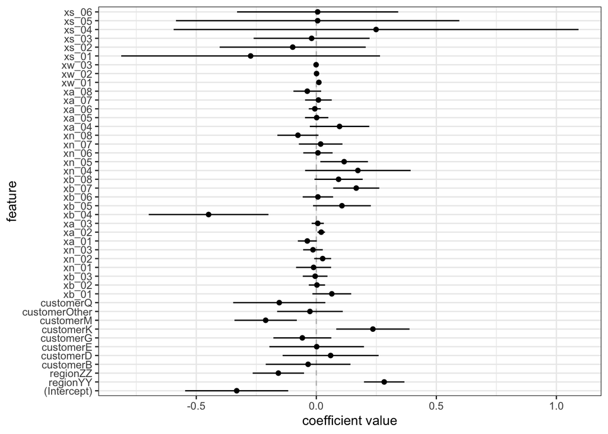

```r
viz_post_coefs(laplace_3_weak$mode[1:ncol(Xmat_3_train)],
               sqrt(diag(laplace_3_weak$var_matrix)[1:ncol(Xmat_3_train)]),colnames(Xmat_3_train))
```

### for your best model:study the posterior uncertainty in the noise(residual error),$\sigma$,how does the lm() maximum likelihood estimate(MLE) on $\sigma$ relate to the posterior uncertainty on $\sigma$?

```r
model_lm_3<-readr::read_rds('model_lm_3.rds')
model_lm_3%>%summary()
```

```
##
## Call:
## lm(formula = log_response ~ ., data = df_all %>% select(-rowid,
##     -outcome, -response))
##
## Residuals:
##      Min       1Q   Median       3Q      Max
## -1.09325 -0.19510 -0.00288  0.19697  1.55830
##
## Coefficients:
##                 Estimate Std. Error t value Pr(>|t|)
## (Intercept)   -0.1669985  0.0972122  -1.718 0.086308 .
## regionYY       0.2773254  0.0368271   7.530 1.75e-13 ***
## regionZZ      -0.2237414  0.0482942  -4.633 4.38e-06 ***
## customerB     -0.1268227  0.0792864  -1.600 0.110197
## customerD     -0.0680785  0.0861122  -0.791 0.429486
## customerE     -0.0987833  0.0870483  -1.135 0.256884
## customerG     -0.1083341  0.0540328  -2.005 0.045392 *
## customerK      0.2258940  0.0694501   3.253 0.001204 **
## customerM     -0.1961907  0.0577286  -3.398 0.000720 ***
## customerOther -0.0505227  0.0620174  -0.815 0.415577
## customerQ     -0.2305592  0.0859905  -2.681 0.007527 **
## xb_01          0.0081990  0.0345362   0.237 0.812420
## xb_02          0.0218299  0.0146159   1.494 0.135787
## xb_03          0.0262128  0.0218907   1.197 0.231583
## xn_01         -0.0013212  0.0328519  -0.040 0.967933
## xn_02          0.0170421  0.0152156   1.120 0.263121
## xn_03         -0.0032394  0.0186148  -0.174 0.861904
## xa_01         -0.0187389  0.0173931  -1.077 0.281722
## xa_02          0.0146374  0.0070563   2.074 0.038448 *
## xa_03         -0.0001943  0.0111639  -0.017 0.986122
## xb_04         -0.3466263  0.1126611  -3.077 0.002183 **
## xb_05          0.0163756  0.0527677   0.310 0.756410
## xb_06         -0.0019072  0.0278762  -0.068 0.945476
## xb_07          0.1577135  0.0435215   3.624 0.000314 ***
## xb_08          0.1109006  0.0454160   2.442 0.014884 *
## xn_04          0.2100798  0.0999153   2.103 0.035897 *
## xn_05          0.0872328  0.0429097   2.033 0.042475 *
## xn_06          0.0235933  0.0272332   0.866 0.386631
## xn_07         -0.0086688  0.0410514  -0.211 0.832824
## xn_08         -0.0951218  0.0386279  -2.463 0.014062 *
## xa_04          0.0405829  0.0548735   0.740 0.459834
## xa_05          0.0126008  0.0225470   0.559 0.576451
## xa_06         -0.0100157  0.0111866  -0.895 0.370952
## xa_07          0.0199217  0.0244745   0.814 0.415964
## xa_08         -0.0144509  0.0246026  -0.587 0.557162
## xw_01          0.0134239  0.0029352   4.573 5.78e-06 ***
## xw_02          0.0002496  0.0015209   0.164 0.869696
## xw_03         -0.0028942  0.0016789  -1.724 0.085217 .
## xs_01         -0.2029905  0.2489528  -0.815 0.415163
## xs_02         -0.1794775  0.1397968  -1.284 0.199666
## xs_03         -0.0242163  0.1130385  -0.214 0.830436
## xs_04         -0.1352323  0.3836254  -0.353 0.724572
## xs_05          0.1247916  0.2716155   0.459 0.646074
## xs_06          0.0908242  0.1509106   0.602 0.547496
## ---
## Signif. codes:  0 '***' 0.001 '**' 0.01 '*' 0.05 '.' 0.1 ' ' 1
##
## Residual standard error: 0.3161 on 633 degrees of freedom
## Multiple R-squared:  0.673,  Adjusted R-squared:  0.6508
## F-statistic: 30.29 on 43 and 633 DF,  p-value: < 2.2e-16
```

Based on the summary table above, the residual standard error is 0.3161 on 633 degrees of freedom.

```r
noise_of_model_best<-stats::sigma(model_lm_3)
noise_of_model_best
```

```
## [1] 0.3160936
```

```r
varphi_uncertainty<-sqrt(diag(laplace_3_weak$var_matrix)[length(laplace_3_weak$mode)])
sigma_uncertainty<-exp(varphi_uncertainty)
varphi_value<-laplace_3_weak$mode[length(laplace_3_weak$mode)]
uncertainty_sigma<-exp(varphi_value)
uncertainty_sigma
```

```
## [1] 0.2959155
```

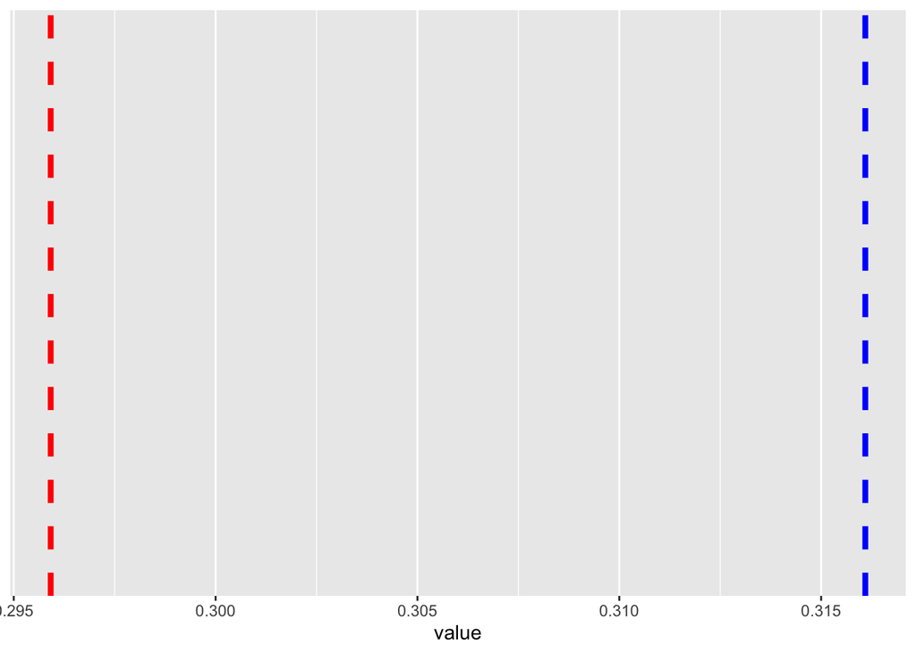

```r
ggplot() +
geom_vline(xintercept = uncertainty_sigma,
          color = "red", linetype = "dashed", size = 1.5) +
geom_vline(xintercept = noise_of_model_best,
          color = "blue", linetype = "dashed", size = 1.5) +
  labs(x='value')
```

Based on the figure above, the blue line is the noise of model_best, and the red line is the posterior uncertainty on $\sigma$, the noise of model_best is a little bit larger than the posterior uncertainty on $\sigma$,but they are very close.

### 6)Do you feel the posterior is precise or are we quite uncertain about $\sigma$

Based on the results above, the posterior is precise enough, since the difference between the posterior uncertainty and the noise of model is not very obvious, which might due to the prior.